# String Manipulation and Map Function

Uni Lee

11/29/2020

We are taking on the role of as an analyst for a book company. The company has provided us more data on some of its 2019 book sales, and it wants us to extract some usable knowledge from it. It launched a new program encouraging customers to buy more books on July 1st, 2019, and it wants to know if this new program was successful at increasing sales and improving review quality. As the analyst, this will be your job to figure out for the guided project.

# Data exploration

```r
raw <- read.csv("data/2_sales2019.csv")
str(raw)
```

```
## 'data.frame':    5000 obs. of  5 variables:
##  $ date                 : chr  "2019-05-22" "2019-11-16" "2019-06-27" "2019-11-06" ...
##  $ user_submitted_review: chr  "it was okay" "Awesome!" "Awesome!" "Awesome!" ...
##  $ title                : chr  "Secrets Of R For Advanced Students" "R For Dummies" "R For Dummies" "Fundamentals of R For Beginners" ...
##  $ total_purchased      : int  7 3 1 3 NA 1 5 NA 7 1 ...
##  $ customer_type        : chr  "Business" "Business" "Individual" "Individual" ...
```

```r
# Column names
names(raw) # variable names
```

```
## [1] "date"                  "user_submitted_review" "title"
## [4] "total_purchased"       "customer_type"
```

```r
# types of columns are...
for (col in colnames(raw)) {
  paste0(col, " : ", typeof(raw[[col]])) %>% print()
}
```

```
## [1] "date : character"
## [1] "user_submitted_review : character"
## [1] "title : character"
## [1] "total_purchased : integer"
## [1] "customer_type : character"
```

```r
# Missing data?
for (col in colnames(raw)) {
  paste0(col,
         ", number of rows with missing data: ",
         is.na(raw[[col]]) %>%  sum) %>% print
}
```

```
## [1] "date, number of rows with missing data: 0"
## [1] "user_submitted_review, number of rows with missing data: 456"
## [1] "title, number of rows with missing data: 0"
## [1] "total_purchased, number of rows with missing data: 718"
## [1] "customer_type, number of rows with missing data: 0"
```

# Handle missing data

Missing data in user review column will have to be eliminated. However, we can preserve data by replacing NAs in total_purchased column with average value.

```r
# Remove NAs in review column
sales_a <- raw %>% filter(!is.na(user_submitted_review))

# Calculate average of total purchase
average <- raw %>% filter(!is.na(total_purchased)) %>%
  summarize(average = mean(total_purchased)) %>% pull()

# Replace NAs with average values
sales_b <- sales_a %>% mutate(
  purchase = ifelse(is.na(total_purchased),
                    average,
                    total_purchased)
  )
```

# String Manipulation to Process Review Data

```r
# Unique reviews
unique(sales_b$user_submitted_review)
```

```
##  [1] "it was okay"
##  [2] "Awesome!"
##  [3] "Hated it"
##  [4] "Never read a better book"
##  [5] "OK"
##  [6] "The author's other books were better"
##  [7] "A lot of material was not needed"
##  [8] ""
##  [9] "Would not recommend"
## [10] "I learned a lot"
```

```r
# Found an NA that was read as a valid string (""). Replace it with NA
sales_b$user_submitted_review[sales_b$user_submitted_review==""] <- NA
# And clean it again
sales_b <- sales_b %>% filter(!is.na(user_submitted_review))
```

When examining unique reviews, we can see that positive reviews contain words like “awesome”, “learned a lot”. Negative reviews contains words like “hate”, “not recommend”. Neutral reviews contain words like “okay”, “OK”.

```r
# This is a function that detects whether the review was positive or negative.

is_positive <- function(review) {
  review_positive = case_when(
    str_detect(review, "Awesome") ~ TRUE,
    str_detect(review, "learned") ~ TRUE,
    TRUE ~ FALSE
  )
}

sales_b <- sales_b %>%
  mutate(is_positive = unlist
         (map(user_submitted_review, is_positive)))
```

# Analysis

## Was the new book program effective in increasing book sales?

The analysis below shows that the marketing program increased sales for Secrets of R For Advanced Students and R For Dummies. For other books, the marketing program had either negligible or negative effect on sales.

```r
# Create a dummy variable that tells whether the purchase was made before or after the marketing program
sales_b <- sales_b %>% mutate(
  after = if_else(ymd(date) >= ymd("2019/07/01"), TRUE, FALSE)
  )

# Purchase before and after the marketing program
summary <- sales_b %>% group_by(after, title) %>%
  summarize(purchase = sum(purchase)) %>% arrange(title, after) %>% as_data_frame()
summary %>% kable() %>% kable_styling()
```

| after | title | purchase |
| --- | --- | --- |
| FALSE | Fundamentals of R For Beginners | 3096.0383 |
| TRUE | Fundamentals of R For Beginners | 2834.9654 |
| FALSE | R For Dummies | 2627.7651 |
| TRUE | R For Dummies | 2780.9199 |
| FALSE | R Made Easy | 15.0000 |
| TRUE | R Made Easy | 24.0000 |
| FALSE | R vs Python: An Essay | 1271.3097 |
| TRUE | R vs Python: An Essay | 1173.3734 |
| FALSE | Secrets Of R For Advanced Students | 966.3552 |
| TRUE | Secrets Of R For Advanced Students | 1155.4372 |
| FALSE | Top 10 Mistakes R Beginners Make | 241.0729 |
| TRUE | Top 10 Mistakes R Beginners Make | 228.0729 |

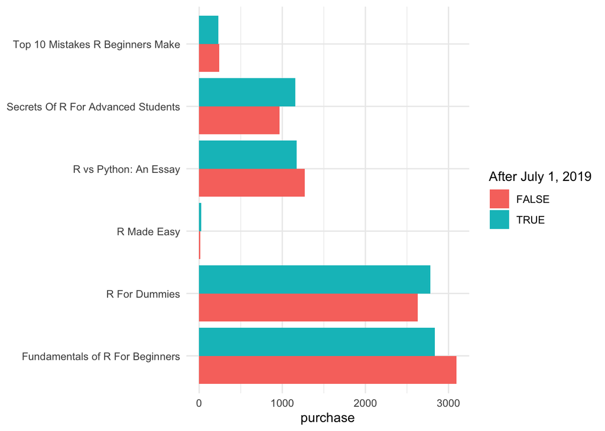

```r
ggplot(summary, aes(x=purchase, y=title, fill=after)) +
  geom_bar(stat="identity", position=position_dodge()) +
  theme_minimal() +
  theme(axis.title.y=element_blank()) +
  labs(fill = "After July 1, 2019")
```

## Did it have a different effect on different customers?

The analysis below shows that the marketing program had a more positive effect on business customers.

```r
summary2 <- sales_b %>% group_by(after, customer_type) %>%
  summarize(purchase = sum(purchase)) %>% arrange(after, customer_type) %>% as_data_frame()
summary2 %>% kable() %>% kable_styling()
```

| after | customer_type | purchase |
| --- | --- | --- |
| FALSE | Business | 5616.776 |
| FALSE | Individual | 2600.765 |
| TRUE | Business | 5747.013 |
| TRUE | Individual | 2449.756 |

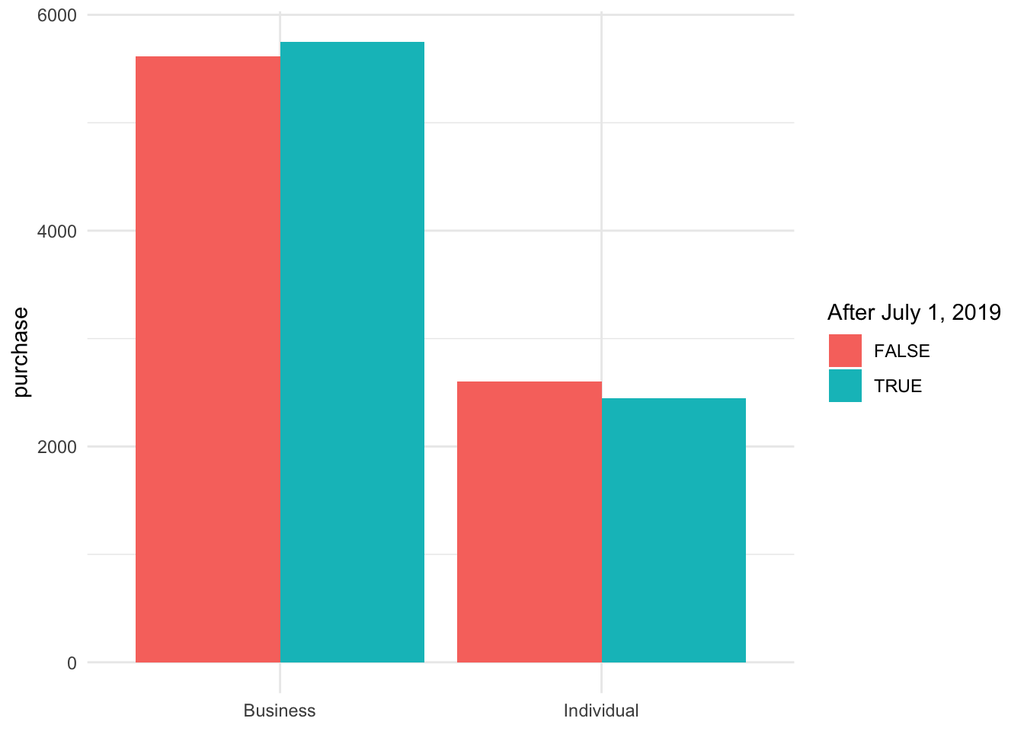

```r
ggplot(summary2, aes(x=customer_type, y=purchase, fill=after)) +
  geom_bar(stat="identity", position=position_dodge()) +
  theme_minimal() +
  labs(fill = "After July 1, 2019") +
  theme(axis.title.x = element_blank())
```